# Dodgers 2027 Hitting Forecasts

2026-10-23

## Research question

Which Dodgers hitters project the strongest combination of 2027 availability and offensive performance, and how much does Statcast add beyond traditional batting statistics?

We separate:

- **Playing time:** probability of reaching at least 150 PA.
- **Conditional performance:** next-season wRC+ among hitters who reach 150 PA.

The final holdout is 2026; the application forecast is 2027. The decision focus is the Dodgers roster.

## Data and audit

- FanGraphs all-player batting exports: 2015–2026.
- Baseball Savant season-level Statcast exports: 2015–2026.
- Chadwick Register: stable FanGraphs-to-MLBAM identifier mapping.

The 2015–2025 audit found complete eligible cross-source joins and no duplicate player-season keys. Primary non-2020 retention ranged from approximately 74% to 79%.

| Check | Result |
| --- | --- |
| Development seasons | 2015–2025 |
| Primary PA threshold | 150 PA |
| 2026 holdout | Used once for final evaluation |
| Primary transitions | Eight, excluding 2020 |

## EDA: what the data say

2020 is included descriptively but excluded from primary transitions because it was a shortened season with an unusual playing-time environment and tracking-system transition.

For Dodgers roster planning, 150 PA preserves a useful sample while avoiding the noisiest part-time population. A 300 PA screen would focus review on regular players, but it would exclude legitimate role-player forecasts.

## EDA: threshold sensitivity

Retention declines as the prior-season playing-time threshold increases. We keep 150 PA as the primary modeling threshold and use 300 PA only as a stricter review sensitivity.

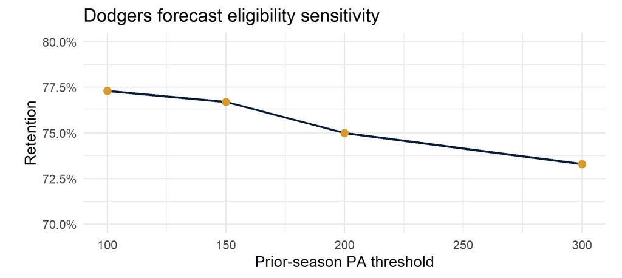

## Model design

The historical feature set uses PA, wRC+, wOBA, ISO, BB%, and K%. The augmented model adds xwOBA, hard-hit rate, barrel rate, sweet-spot rate, and average exit velocity.

**Frozen choices**

- Historical logistic model for playing-time eligibility.
- Historical + Statcast ridge model for conditional wRC+.
- Fixed XGBoost versions retained as sensitivity analyses.

All imputation and scaling occur inside the model pipeline.

## Model comparison

| Model | Development_ROC_AUC | Development_wRC_MAE |
| --- | --- | --- |
| Historical ridge | 0.808 | 18.11 |
| Historical + Statcast ridge | 0.809 | 17.63 |
| Historical + Statcast XGBoost | 0.807 | 17.59 |

The Statcast addition helps conditional wRC+ modestly. XGBoost does not provide enough improvement to replace the simpler ridge model.

## 2026 holdout test

| Metric | Result |
| --- | --- |
| Eligibility accuracy | 80.2% |
| Eligibility ROC AUC | 0.800 |
| Eligibility Brier | 0.146 |
| Conditional wRC+ MAE | 17.0 |
| Conditional wRC+ RMSE | 21.4 |

## Forecasting 2027

The selected models were refit through 2026 and applied to Dodgers hitters with at least 150 PA in 2026.

The strict review screen requires:

## Dodgers forecast shortlist

| Player | 2026 PA | 2026 wRC+ | 2027 predicted wRC+ | Eligibility probability |
| --- | --- | --- | --- | --- |
| Shohei Ohtani | 618 | 139.2 | 128.2 | 1.0 |
| Will Smith | 276 | 117.9 | 112.8 | 0.8 |
| Freddie Freeman | 657 | 119.9 | 112.6 | 1.0 |
| Max Muncy | 561 | 128.9 | 112.0 | 1.0 |
| Mookie Betts | 528 | 113.6 | 107.5 | 1.0 |
| Andy Pages | 574 | 122.8 | 106.6 | 1.0 |
| Kyle Tucker | 627 | 100.1 | 105.8 | 1.0 |
| Teoscar Hernandez | 491 | 109.6 | 103.9 | 0.9 |

## Dodgers forecast chart

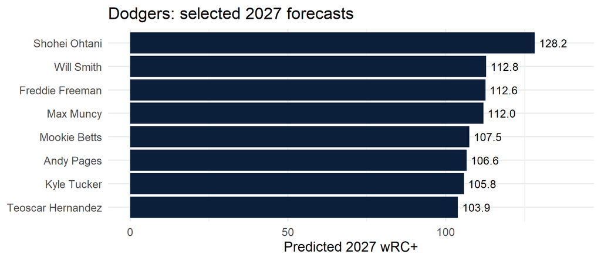

## Dodgers player review priorities

| Player | 2026 PA | 2026 wRC+ | Pred. 2027 wRC+ | Eligible | Lift |
| --- | --- | --- | --- | --- | --- |
| Shohei Ohtani | 618 | 139.2 | 128.2 | 1.0 | -11.0 |
| Will Smith | 276 | 117.9 | 112.8 | 0.8 | -5.1 |
| Freddie Freeman | 657 | 119.9 | 112.6 | 1.0 | -7.3 |
| Max Muncy | 561 | 128.9 | 112.0 | 1.0 | -17.0 |

These are Dodgers roster-planning priorities, not automatic acquisition recommendations. Add health, roster status, defensive role, and expected playing time during baseball review.

## Limitations

- Only five expanding development folds were available.
- 2020 is not exchangeable with a normal season.
- Statcast missingness is non-random and flagged in the forecast output.
- No age, injury, contract, park, role, or roster-context variables are modeled.
- 2027 outcomes are not yet available.
- Forecasts are predictive and associative, not causal.

## Reproducibility and handoff

Project files:

- [Complete ranked forecast table](https://github.com/transCoderJen/Dodgers-2027-Hitting-Forecasts/blob/master/data/forecasts/player_forecasts_2027.csv)
- [Dodgers forecast shortlist](https://github.com/transCoderJen/Dodgers-2027-Hitting-Forecasts/blob/master/data/forecasts/dodgers_forecast_shortlist_2027.csv)
- [Forecast-building script](https://github.com/transCoderJen/Dodgers-2027-Hitting-Forecasts/blob/master/scripts/build_2027_forecasts.py)
- [Forecast pipeline tests](https://github.com/transCoderJen/Dodgers-2027-Hitting-Forecasts/blob/master/tests/test_forecast_pipeline.py)
- [Project requirements](https://github.com/transCoderJen/Dodgers-2027-Hitting-Forecasts/blob/master/requirements.txt)
- [Complete project repository on GitHub](https://github.com/transCoderJen/Dodgers-2027-Hitting-Forecasts)